# EloとGlicko(2)レーティング

UPDATE: 2025-11-02 23:44:41.017317

# はじめに

内容をまとめるにあたり、下記を参考にしており、下記に沿うような形で自分の中で行間を埋めてみた。

- [レーティングの理論 (Eloレーティング, Glickoレーティング) | henatips](https://henatips.com/page/26/)

## Eloレーティング

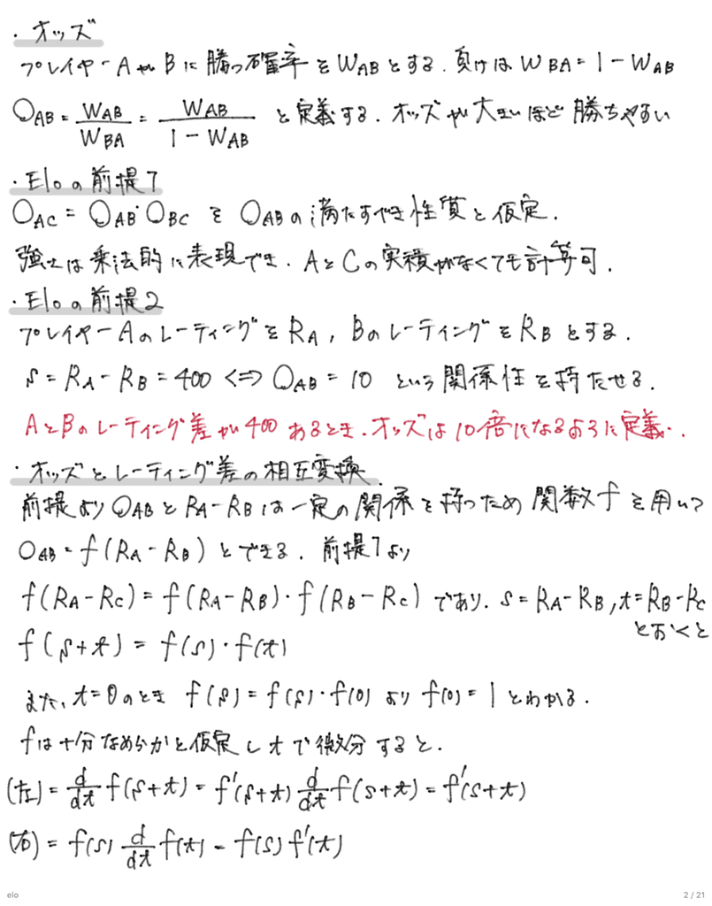

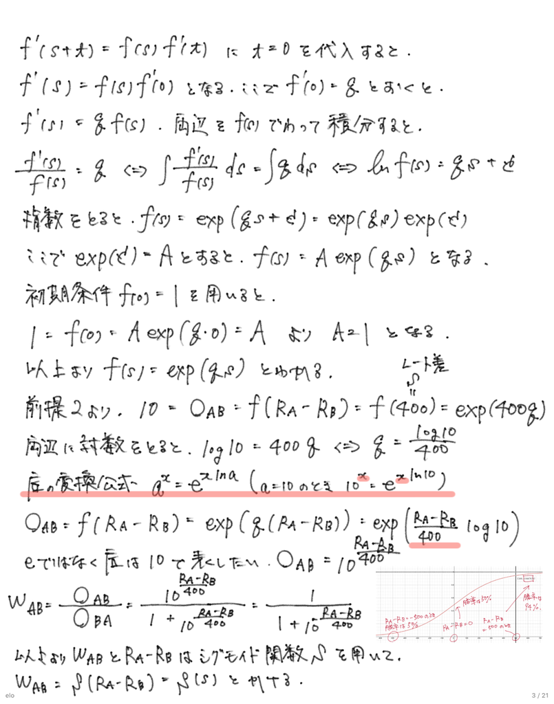

## Glickレーティング

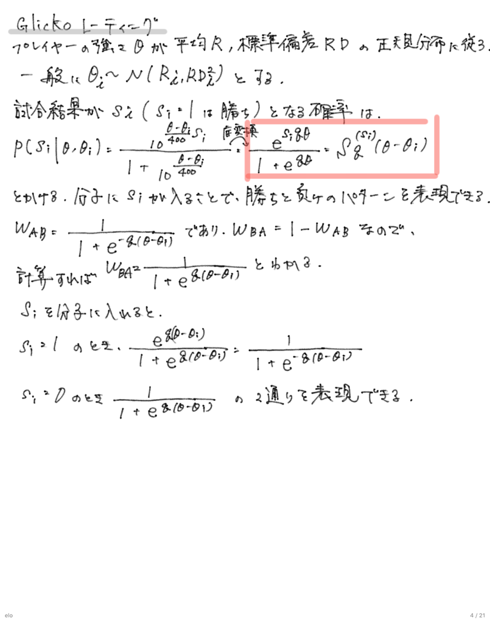

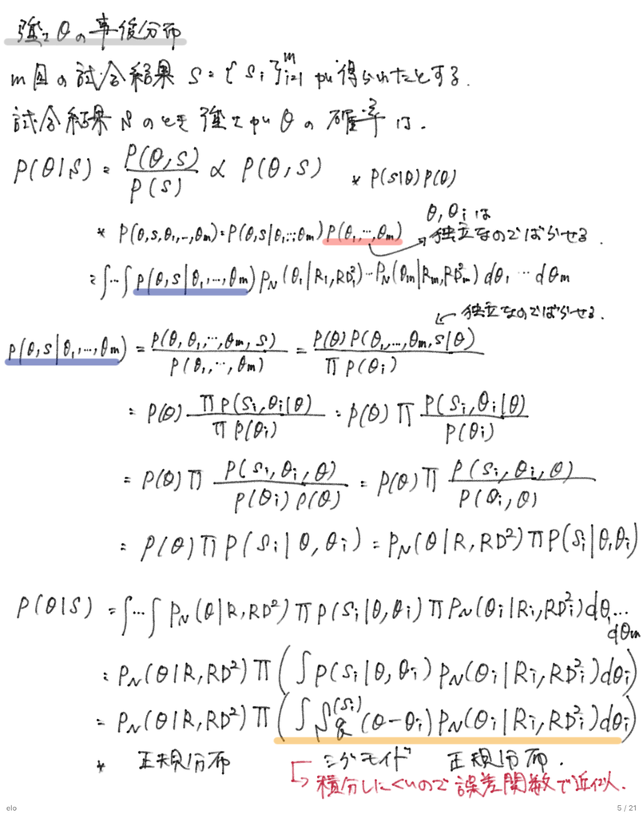

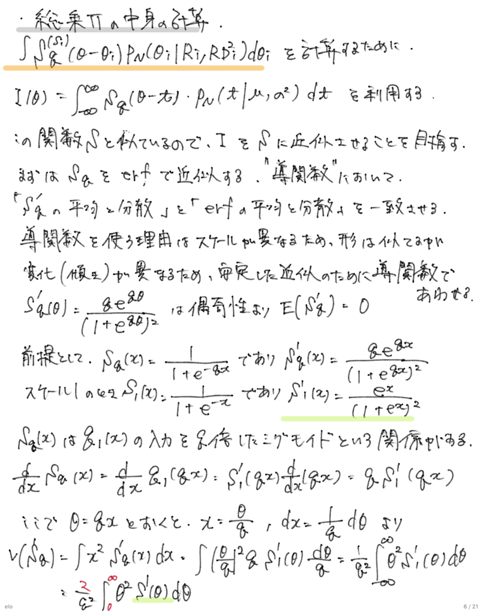

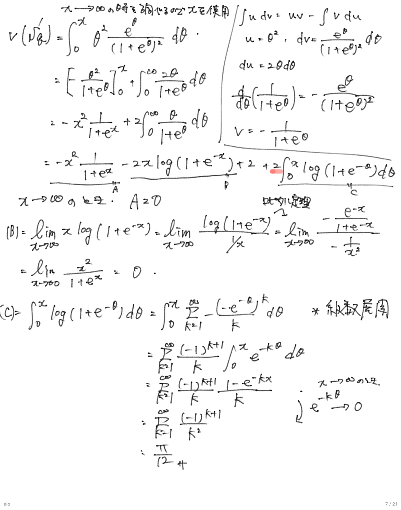

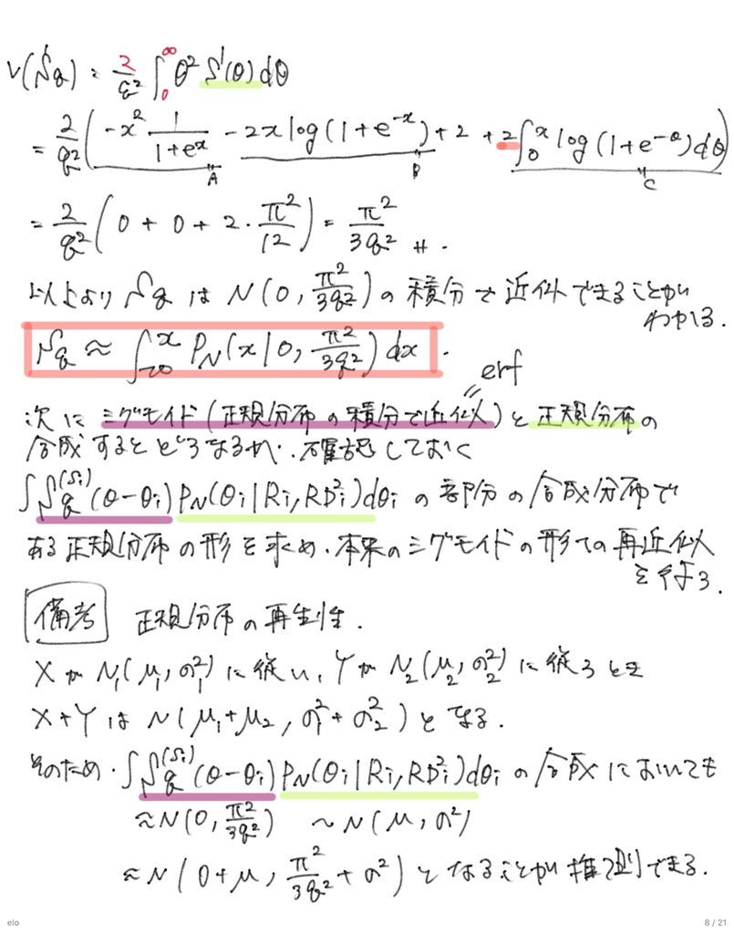

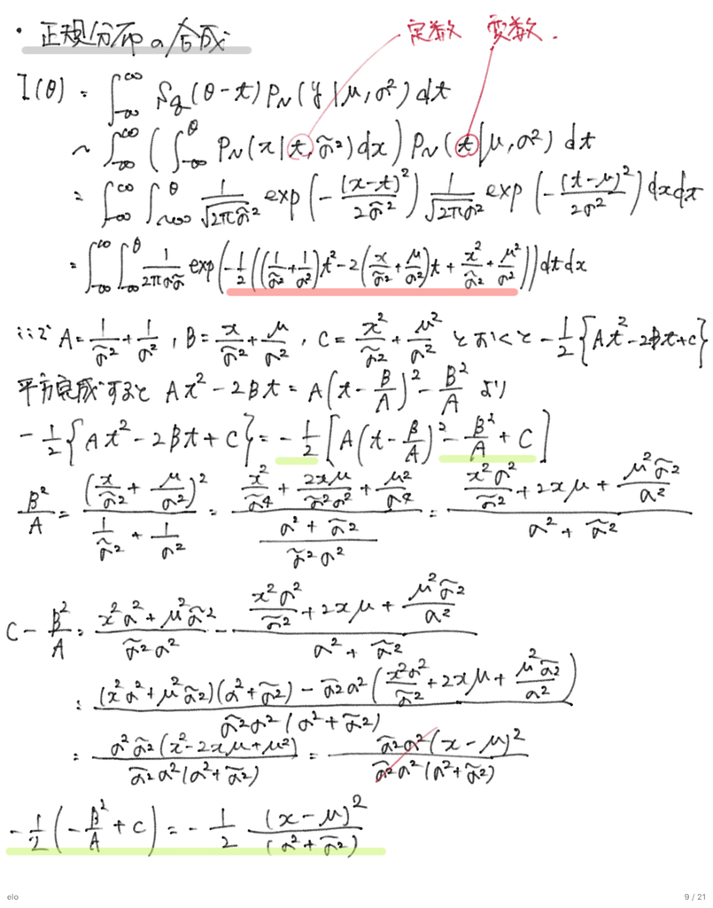

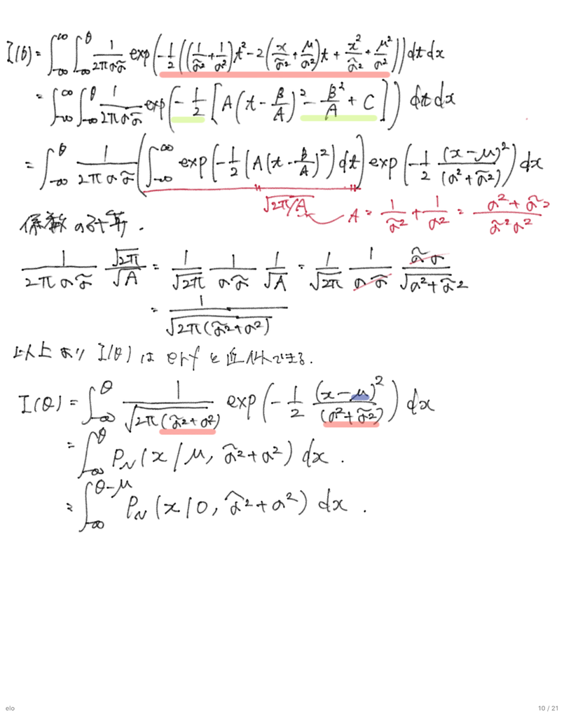

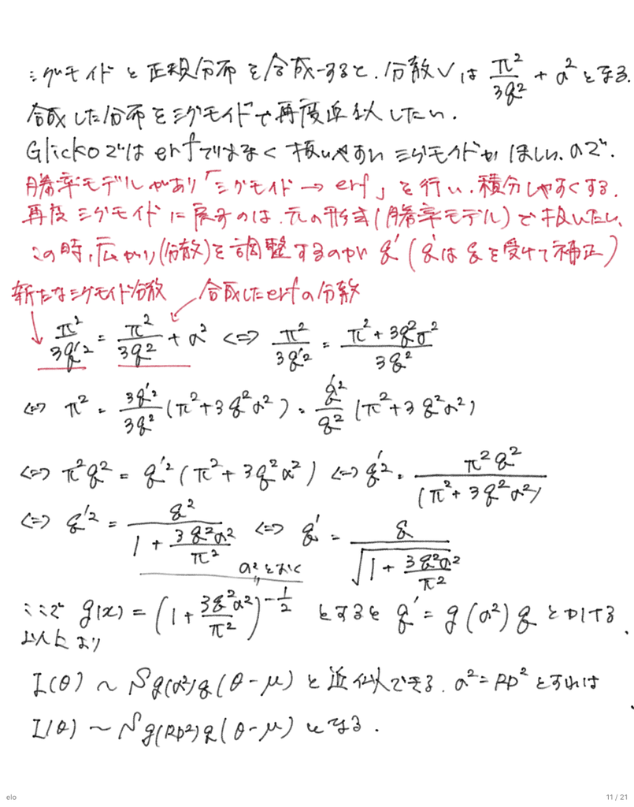

作図のグラフコード。Pythonで書くのであればrmdではなくipynbでいい気もするが、ベイズシリーズがrmdなので。

```
import numpy as np
import matplotlib.pyplot as plt
from math import pi, sqrt
from scipy.stats import norm

# -----------------------------
# Parameters
# -----------------------------
q = 1.6
mu = 0.0
sigma = 1.0


def sigmoid(x, q_):
    return 1.0 / (1.0 + np.exp(-q_ * x))


# sigmoid ~ Normal (variance matching)
sd0 = pi / (sqrt(3) * q)
sd_after = np.sqrt(sd0**2 + sigma**2)

# q' for re-sigmoization (variance matching)
q_prime = q / np.sqrt(1.0 + (3.0 * q**2 * sigma**2) / (pi**2))

x = np.linspace(-6, 6, 600)

# -----------------------------
# Figure 1: Original sigmoid vs. normal CDF (variance matched)
# -----------------------------
plt.figure(figsize=(6, 4))
plt.plot(x, sigmoid(x, q), label="Original sigmoid σ_sig = π/(√3 q)")
plt.plot(x, norm.cdf((x - mu) / sd0), linestyle="--", label="Normal CDF (variance matched)")
plt.title("Step 1: Sigmoid → Normal CDF (variance matching)")
plt.xlabel("x")
plt.ylabel("Probability")
plt.legend()
plt.grid(True)
plt.show()

# -----------------------------
# Figure 2: After convolution vs. re-sigmoization (q')
# -----------------------------
plt.figure(figsize=(6, 4))
plt.plot(x, norm.cdf((x - mu) / sd_after), label="After convolution (Normal CDF, sd=√(sd0²+σ²))")
plt.plot(x, sigmoid(x - mu, q_prime), linestyle="--", label="Re-sigmoidization (using q')")
plt.title("Step 2: Normal×Normal convolution → Back to sigmoid (q')")
plt.xlabel("x")
plt.ylabel("Probability")
plt.legend(loc='upper left')  # 凡例を左上に
plt.grid(True)
plt.show()

# Summary
print("=== Parameter Summary ===")
print(f"q        = {q:.6f}")
print(f"mu       = {mu:.6f}")
print(f"sigma    = {sigma:.6f}")
print(f"sd0      = π/(√3 q)           = {sd0:.6f}")
print(f"sd_after = √(sd0² + σ²)       = {sd_after:.6f}")
print(f"q'       = q / √(1 + 3 q² σ² / π²) = {q_prime:.6f}")
```

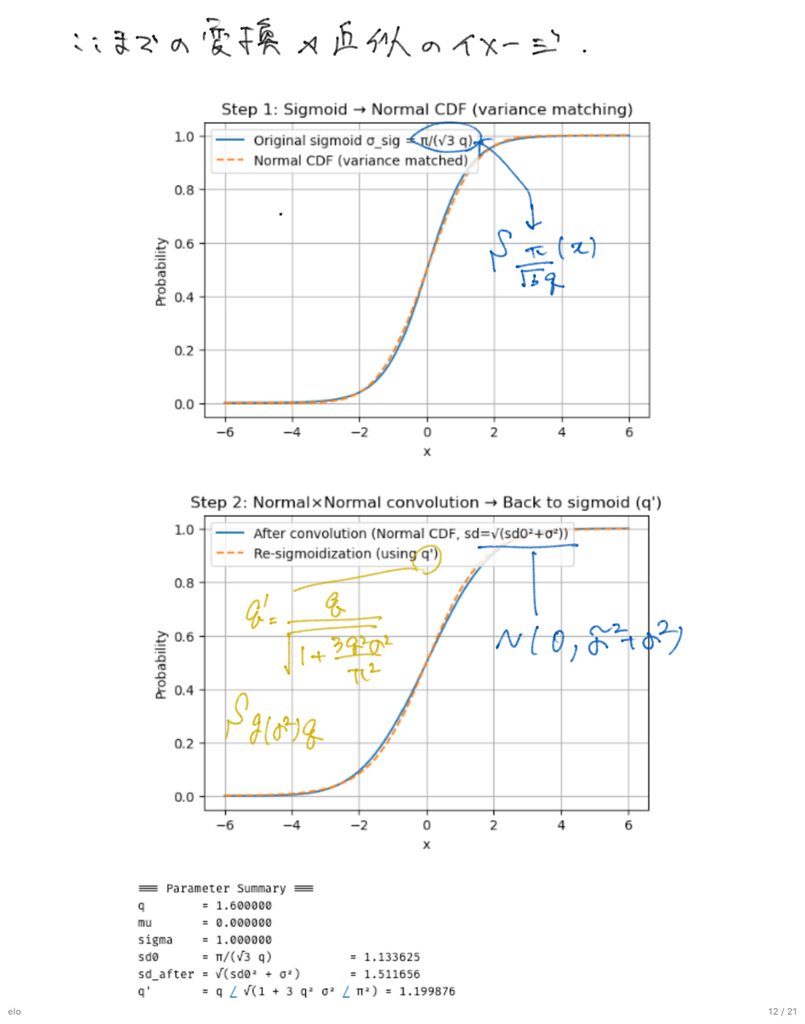

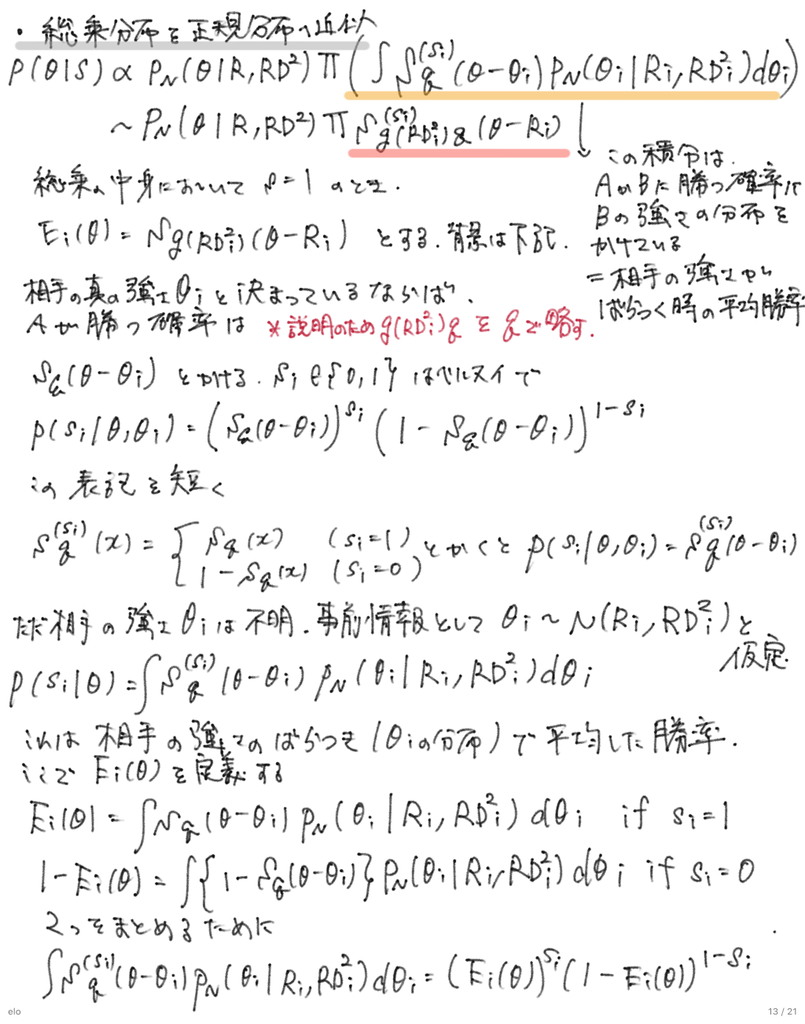

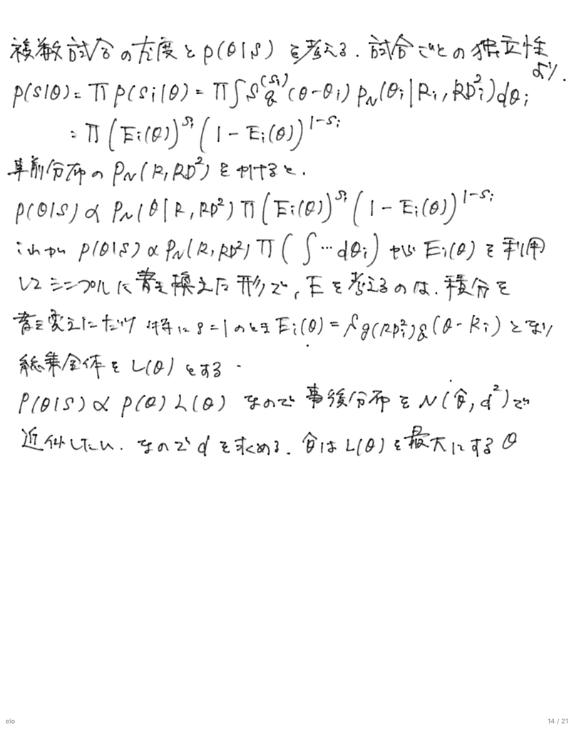

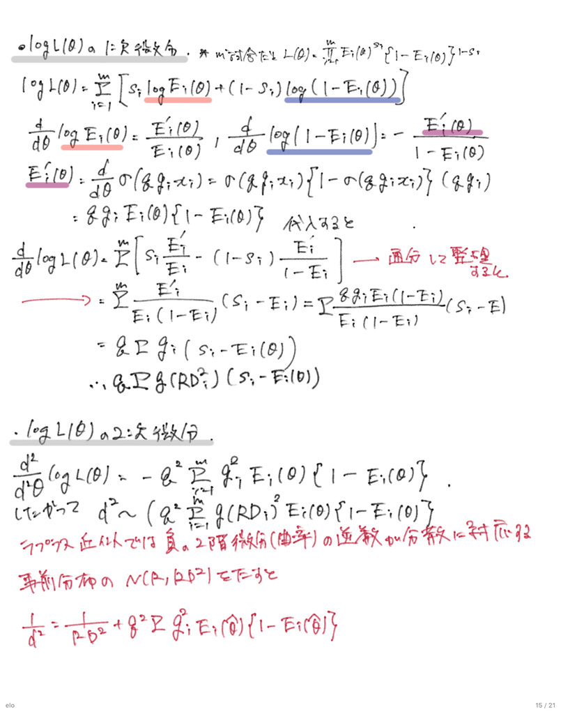

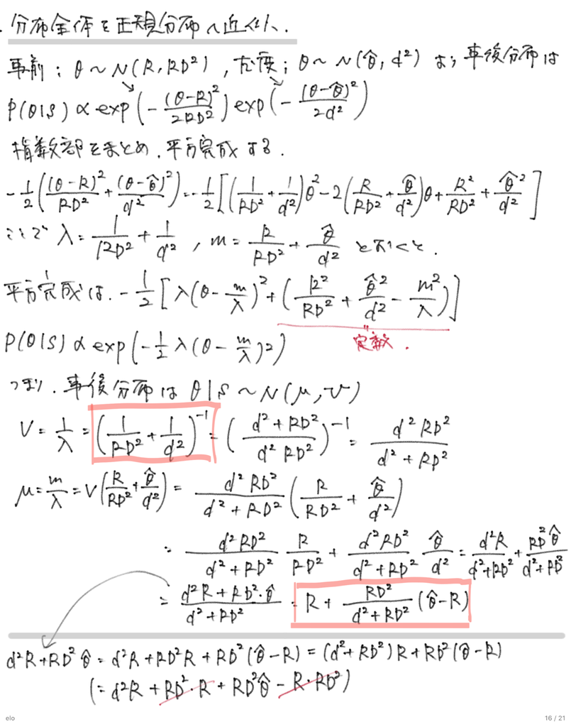

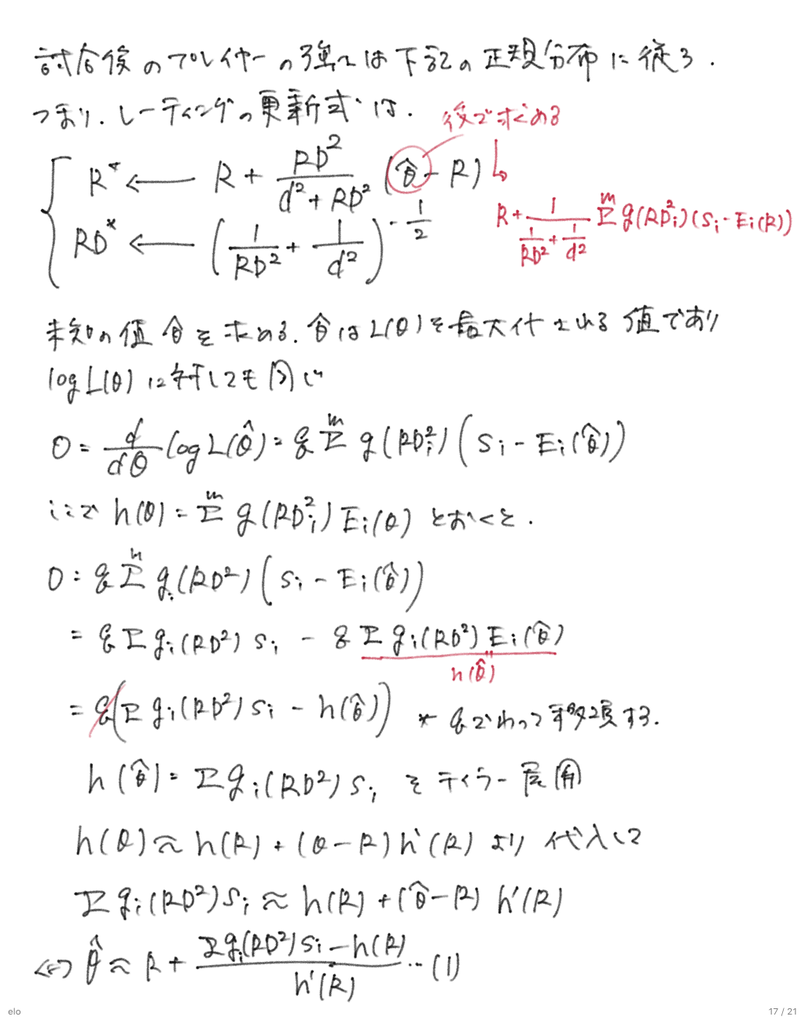

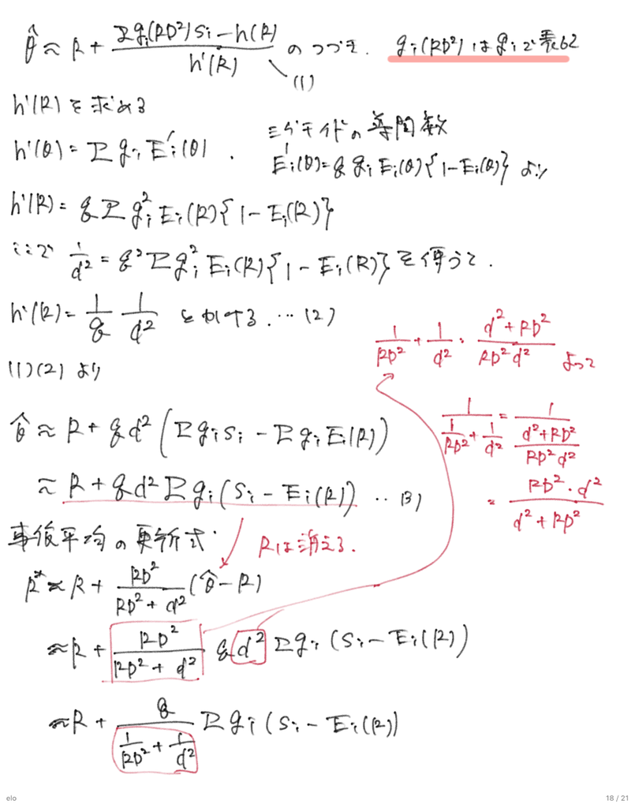

## Glick2レーティング

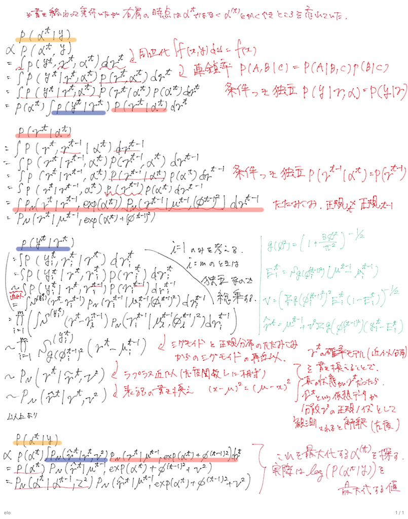

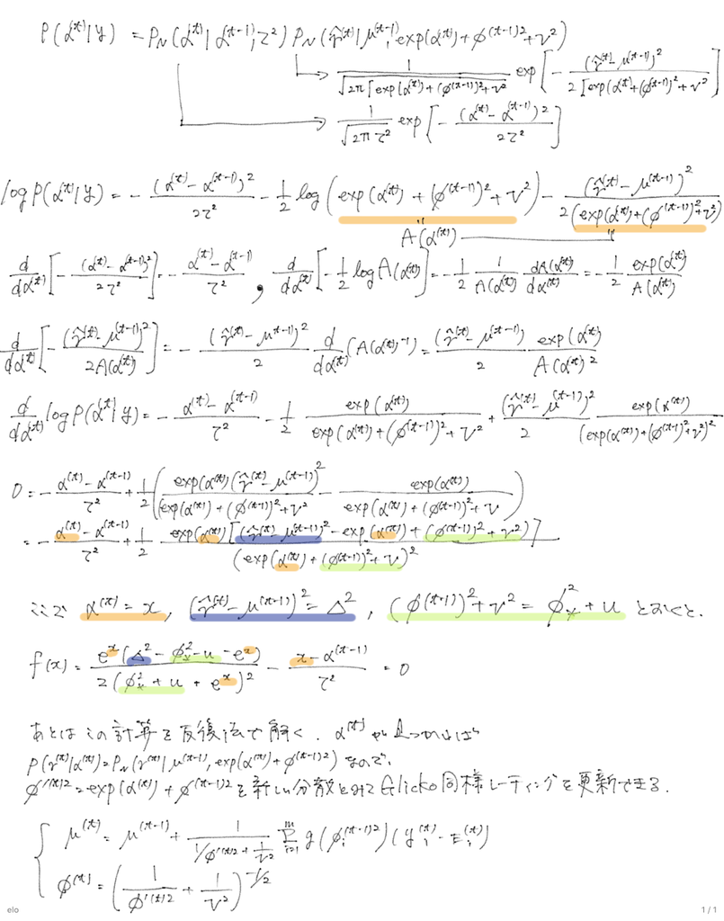

## 参考文献および参考資料

- [レーティングの理論 (Eloレーティング, Glickoレーティング) | henatips](https://henatips.com/page/26/)